# 36-315 Homework 2, Fall 2021

SOLUTIONS

Due Tuesday, September 14, 2021 (11:59pm ET) on Gradescope

## Homework 02: Graphical Inference for 1D Categorical Data

# Problem 1: Statistical Tests for Categorical Data (22pts)

For this problem, we will again use the Titanic data, which you saw in Homework1:

```r
#  Load the data into R
titanic <- read.csv("https://raw.githubusercontent.com/zjbranson/315Fall2021/master/titanic.csv")
```

1. (5pts) As a review of last week’s material, first make a graph that shows the marginal distribution of the `Pclass` variable. You can make any graph you want, as long as it appropriately displays the marginal distribution for `PClass`. When making your graph, be sure that:
- Your axes are properly labeled
- The graph has a proper title
- You change the color of your plot such that it doesn’t use default colors (i.e., colors automatically chosen by `R`).

After making your plot, describe the marginal distribution of `Pclass` in 1-2 sentences. In your answer, do not simply refer to “1”, “2”, and “3” – you need to figure out what these categories mean in terms of the titanic data. (**Hint**: As discussed in Homework1, further details about the variables can be found [here](https://www.kaggle.com/c/titanic/data). See Variable Notes on that page.)

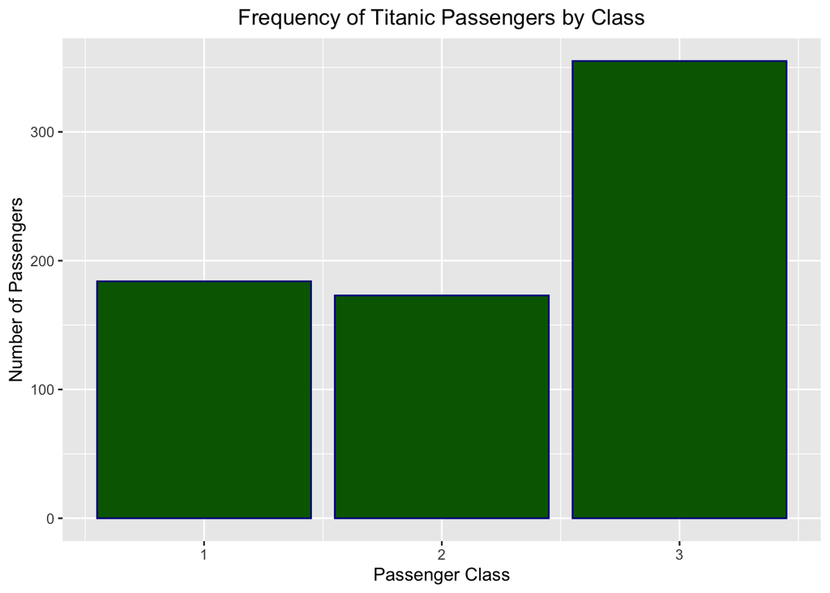

```r
library(tidyverse)
ggplot(data = titanic, aes(x = Pclass)) +
  geom_bar(fill = "darkgreen", color = "darkblue") +
  labs(title = "Frequency of Titanic Passengers by Class",
       x = "Passenger Class", y = "Number of Passengers") +
  theme(plot.title = element_text(hjust = 0.5))
```

*Class 1 corresponds to first class, which is the highest socioeconomic status of passengers; similarly, Class 3 corresponds to third class, which is the lowest socioeconomic status. It appears that approximately 1/4 of the passengers are first class, 1/4 are second class, and 1/2 are third class; thus, the near-majority of titanic passengers were of lower socioeconomic status.*

2. (5pts) [Professor M. J. Canino](https://en.wikipedia.org/wiki/RVIVR) looks at your graph in Part A and says to you, “The passengers were equally likely to belong to any of the three classes.” You obviously disagree. You tell Professor Canino to just look at the graph, but they are still unconvinced, arguing that what you see in the graph could just be due to random noise and may not be an actual significant difference.

From the graphs alone, are you able to definitively state whether or not there is a statistically significant difference amongst the proportions of classes? State yes or no, and then provide a one-sentence explanation for your answer.

*No: From the graphs alone, you are not able to definitively state whether or not there is a statistically significant difference amongst the proportions of classes; we need to conduct a formal statistical test to do this.*

3. (6 points) To provide more explicit evidence of statistical significance, what kind of statistical test could you use to show that the passengers are not equally likely to belong to any of the three classes?

After stating the test, run the statistical test, and then formally interpret the results from the test in 1-3 sentences. To receive full credit for this question, you must (1) display the code you used to run the test, (2) state the p-value from the test, and (3) state your formal conclusion from the test. (**Hint**: Even if you do not know the syntax/code for running this test in `R`, you can easily figure it out using Google. Just Google something like, “How to perform ___ test in R”.)

*We can use a chi-square test for equal proportions. Here is the code to run the test:*

```r
chisq.test(table(titanic$Pclass))
```

```
##
##  Chi-squared test for given probabilities
##
## data:  table(titanic$Pclass)
## X-squared = 87.761, df = 2, p-value < 2.2e-16
```

*We see that the p-value is quite small - less than $2.2 \cdot 10^{-16}$. Thus, we reject the null hypothesis that the proportions among the different classes are equal, thereby concluding that they are not all equal (i.e., at least one pair of proportions are not equal). Note that this is different from concluding that all the proportions are not equal to each other.*

4. (6pts) Now we wil make a couple of improvements to your graph in Part A. First, copy-and-paste your code from Part A. Then, make the following two changes to your graph:
- Report the p-value from Part C somewhere on your graph other than the title. If you got an extremely small p-value, it’s fine if you describe the p-value as “chi-squared test p-value approximately zero.”
- Currently, your graph likely has the labels 1, 2, 3, which denote the levels for `Pclass`. Change these to “Upper”, “Middle”, “Lower”, respectively, which are the proper class names for this variable (see Variable Notes for the data [here](https://www.kaggle.com/c/titanic/data)).

For this part, all you have to do is include the desired graph (and corresponding code).

**Hint**: To do the second part, you might have to ensure that `Pclass` is treated as a factor when making your graph. It may also be helpful to visit [this page](http://www.sthda.com/english/wiki/ggplot2-axis-ticks-a-guide-to-customize-tick-marks-and-labels), which uses functions very similar to what we saw in Homework1.

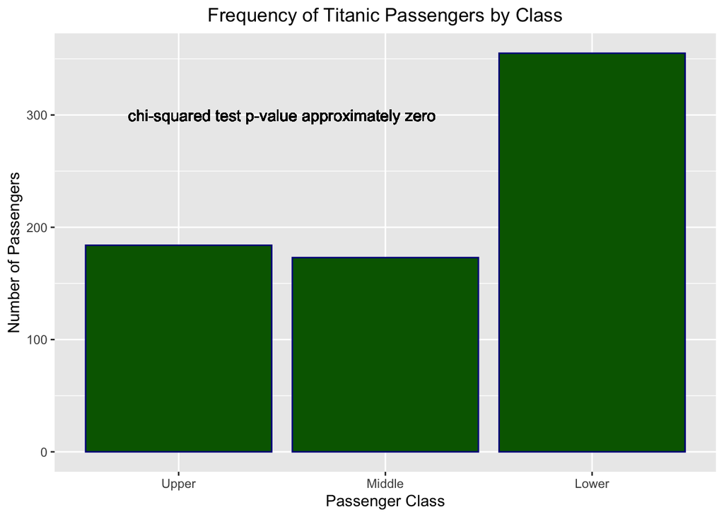

```r
ggplot(data = titanic, aes(x = factor(Pclass))) +
  geom_bar(fill = "darkgreen", color = "darkblue") +
  labs(title = "Frequency of Titanic Passengers by Class",
       x = "Passenger Class", y = "Number of Passengers") +
  theme(plot.title = element_text(hjust = 0.5)) +
  scale_x_discrete(name = "Passenger Class",
    labels = c("Upper", "Middle", "Lower")) +
  geom_text(x = 1.5, y = 300, label = "chi-squared test p-value approximately zero")
```

*For this plot, note that we converted `Pclass` to a factor and use `scale_x_discrete()`, as suggested by the hint, and used `geom_text()` to add a text annotation, as we did in Lab2.*

# Problem 2: Writing and Working with Functions in R (18 points)

Functions can be very useful when making visualizations, especially as our data structures get more complex over the course of the semester. So, in this problem we will get practice writing functions in R. In short, functions are “mini programs” that allow you to reuse code for different variables and datasets. This problem may be a review for you if you’re very familiar with `R`; nonetheless, functions are extremely helpful for making nuanced graphics (as we’ll see in Problem 2).

If you’re unfamiliar with functions in R (or need a refresher), please read Section 5 of the R Intro document (written by Larry Wasserman) on Canvas about writing functions in R. Then, complete the following problems.

1. (3pts) Write an R function called `abssum` that takes four inputs: `a`, `b`, `x`, and `y`, and returns the quantity $ax + b|y|$. Test your function and demonstrate that it works for at least three different combinations of the inputs.

*Here’s the function `abssum()`:*

```r
abssum <- function(a,b,x,y){
  return(a*x + b*abs(y))
}
```

*Now we’ll test our function on several combinations of inputs:*

```r
all(
abssum(1,1,1,1) == 2,
abssum(1,1,1,-1) == 2,
abssum(3,-1,1,-1) == 2,
abssum(3,-1,1,1) == 2 # only 3 required
)
```

```
## [1] TRUE
```

*We see that our function works properly, so we can proceed.*

2. (3pts) Type `abssum(x = 1, y = 1)` into your code block. What happens when you only specify these two arguments? (Note: When knitting your document for submission, comment this line of code out, so that it does not produce an error.)

*We could run the following code (commented out) and get an error:*

```r
# abssum(x = 1, y = 1)
```

*When some of the input values are not specified, we observe an error. The function does not know what values to use for `a` and `b`, but these parameters are required for the function to run.*

3. (3pts) Create a new function, `abssum2`, that has default values for `a = 1`, `b = 1`. Type `abssum2(x = 1, y = 1)` into your code block. What happens when you only specify the two arguments now?

*Here’s the new function:*

```r
abssum2 <- function(a = 1, b = 1, x, y){
  return(abssum(a, b, x, y))
}

abssum2(x = 1, y = 1)
```

```
## [1] 2
```

*When we supply just 2 values for `x` and `y` into abssum2 it uses the default values `a = 1, b = 1` so that values for all parameters are provided for the function.*

4. (3pts) Note that typing `1:10` in `R` produces the numbers 1 through 10. (Try this in the Console.) What happens when you call the function with the following input: `abssum2(x = 1:10, y = 1:10)`? Why does this happen?

```r
abssum2(x = 1:10, y = 1:10)
```

```
##  [1]  2  4  6  8 10 12 14 16 18 20
```

*We see that it calculates `abssum2(1,1)`, `abssum2(2,2)`, …, `abssum2(10,10)` That is, `abssum2(i,i)` for `i` in `1:10`, applying the calculation across the vectors. This happens because all of the calculations within `abssum2()` are vectorized.*

5. (3pts) Use `help(rnorm)` to learn about the function `rnorm`, which generates Normal random variables. Generate 5000 independent standard Normal random variables (i.e., a Normal distribution with mean 0 and variance 1) and assign them to a variable called `Z`. Repeat the same procedure and assign the new values to `W`. Then, uncomment the following code (which uses the base `R` `plot()` function to produce a scatterplot):

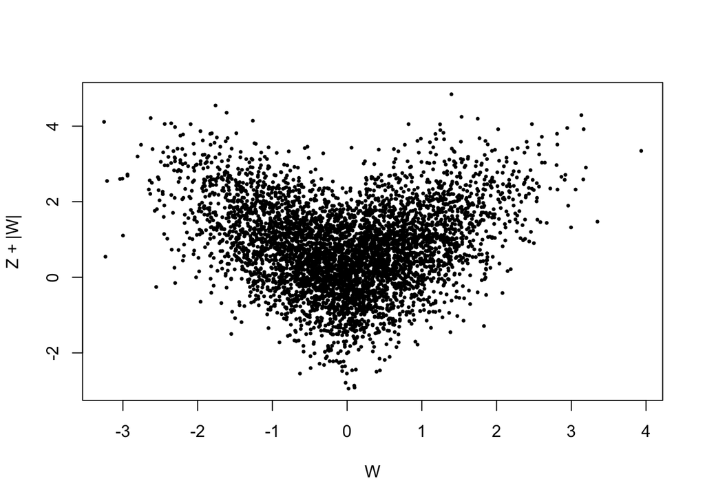

```r
Z = rnorm(5000)
W = rnorm(5000)
plot(W, abssum2(x = Z, y = W), cex = .5, pch = 16, xlab = "W", ylab = "Z + |W|")
```

Describe the graph that shows up, and explain why this happens.

*Since `abssum2(x = Z, y = W)` applies the function $1\cdot z + 1\cdot |w|$ to each pair $(z,w)$ in our 2 vectors, we obtain a V-shape of scattered dots (which looks a lot like a heart). The V-shape is due to the absolute value part of `abssum2()`. If the plot were |W| vs W, it would have a perfect V shape. The random scatter occurs due to the normal variation of Z.*

6. (3pts) Now use `ggplot()` to create the same plot in Part E. Be sure to include a title and axis labels in your plot. All you need to submit for this part is the same scatterplot as Part E, but with `ggplot()`.

**Hint**: The point of this exercise is to demonstrate how you make a plot with `ggplot()` after you’ve created several variables like `W` and `Z`. One frustrating thing about `ggplot()` is that it requires all variables to be contained in a single dataset. So, after you have defined `W` and `Z`, create a data frame with `D = data.frame(V1 = W, V2 = abssum2(x = Z, y = W))`. Then, you can use this dataset to make the same scatterplot via `ggplot()`.

*Here’s the `ggplot` code to make the same plot:*

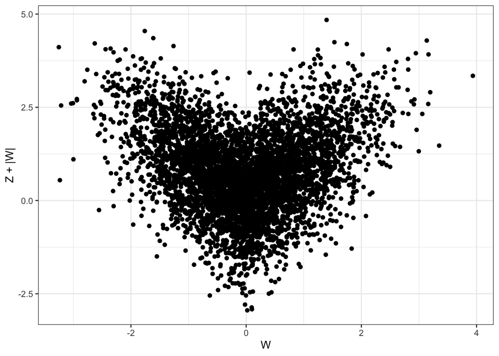

```r
library(tidyverse)
D <- data.frame(V1 = W, V2 = abssum2(x = Z, y = W))
ggplot(D, aes(x = V1,y = V2)) +
  geom_point() +
  labs(x = "W",y = "Z + |W|") +
  theme_bw() # not needed (but feel free to figure out what this did)
```

# Problem 3: Visualizing Cereal Uncertainty (45 points)

In this problem, we will work with a dataset of cereals manufactured in the United States. The following code loads the dataset (called `UScereal`) into `R`:

```r
library(MASS)  #  Load the MASS library
data(UScereal)  #  Load the "UScereal" dataset into your workspace (as a data.frame in R)
help(UScereal) #Help documentation for this dataset
```

1. (4 points) For this problem, we will focus on the manufacturer variable, `mfr`. First, produce a contingency table of the counts of different cereal manufacturers in the dataset. Then, answer the following: Which manufacturer is the most frequent, and which is the least frequent? In your answer, please include the names of the actual manufacturers, rather than just the initials.

```r
table(UScereal$mfr)
```

```
##
##  G  K  N  P  Q  R
## 22 21  3  9  5  5
```

*We see that General Mill’s is the most frequent manufacturer, and Nabisco is the least frequent manufacturer. (Also, note that the other manufacturers are Kelloggs, Post, Quaker Oats, and Ralston Purina.)*

2. (4 points) Produce a bar plot of the `mfr` variable on the count scale. Make the color of the bars something other than gray. Be sure to add appropriate labels and a title to your plot (note that people won’t know what you mean by `mfr`). If you use ggplot to make this plot, center your title by adding the line `theme(plot.title = element_text(hjust = 0.5))` to your code. After making your plot, summarize it in 1-2 sentences.

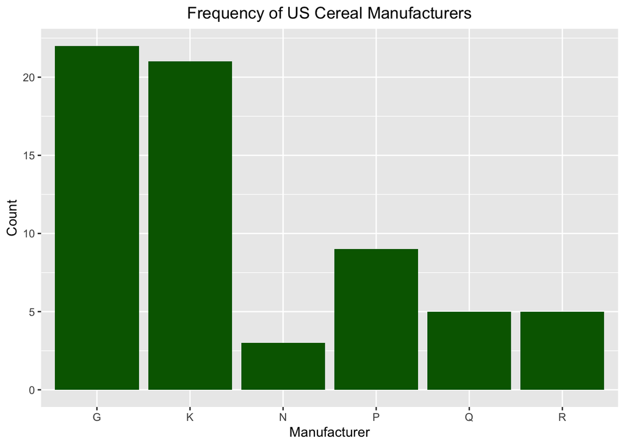

```r
library(ggplot2)
ggplot(data = UScereal) + geom_bar(fill = "darkgreen") + aes(x = mfr) +
labs(x = "Manufacturer", y = "Count", title = "Frequency of US Cereal Manufacturers") +
theme(plot.title = element_text(hjust = 0.5))
```

*We can see that General Mills (G) and Kelloggs (K) are by far the most frequent cereal manufacturers, whereas the other manfacturers (Nabisco, Post, Quaker Oats, and Ralston Purina) have similar frequencies. Within these less-frequent manufacturers, Nabisco is the least frequent and Post is the most frequent, but all of these manufacturers seem to have fairly similar frequencies compared to General Mills nad Kelloggs.*

3. (10pts) Now we’re going to work towards adding confidence intervals to the plot you made in Part B. For this part, write a function called `getPropCI()` that computes the 95% confidence intervals for the *proportion* of each manufacturer. Your function should take in a frequency table `freqTable` produced by the `table()` function:

```r
freqTable = table(UScereal$mfr)
```

To get you started, below is some template code. As you can see from the template code, you must use `freqTable` to do three things:

- Compute the total sample size in `UScereal`
- Compute the proportions of each category of `mfr`
- Compute the standard error of the proportions

Thus, you only need to write three additional lines of code for `getPropCI()`.

```r
getPropCI = function(freqTable, alpha = 0.05){
  #the total sample size is
  n = sum(freqTable)
  #the proportions are
  proportions = freqTable/n
  #the standard error for proportions is
  SE = sqrt((proportions*(1-proportions))/n)
  #the confidence intervals are
  CI.lower = proportions - qnorm(1-alpha/2)*SE
  CI.upper = proportions + qnorm(1-alpha/2)*SE
  CIs = rbind(CI.lower, CI.upper)
  return(CIs)
}
```

After you’ve written `getPropCI()`, uncomment the following line of code such that the confidence intervals display:

```r
getPropCI(freqTable)
```

```
##                  G         K            N         P          Q          R
## CI.lower 0.2234282 0.2093891 -0.004853711 0.0544975 0.01214341 0.01214341
## CI.upper 0.4534949 0.4367648  0.097161404 0.2224256 0.14170274 0.14170274
```

After you’ve successfully displayed your confidence intervals above, answer the following: Is there anything non-intuitive with any of the confidence intervals you’ve computed? State Yes or No, and give a 1-2 sentence explanation.

*Yes, the confidence interval for the proportion of Nabisco manufacturers contains negative numbers, which is non-intuitive, because proportions are strictly between 0 and 1.*

4. (3pts) Given your work in Part C, write one line of code that displays the 95% confidence intervals for the *counts* of each `mfr`. For this part, you just need to write code that displays the confidence intervals.

(**Hint**: Remember that the proportion for any category $j$ is defined as $p_j = \frac{n_j}{n}$, where $n_j$ is the number of category $j$ and $n$ is the total sample size. You already have the confidence interval for $p_j$ and just need the confidence interval for $n_j$.)

*We already obtained the confidence intervals for the proportions; thus, to obtain the confidence intervals for the counts, we can just multiply our confidence intervals by the sample size of the dataset:*

```r
nrow(UScereal)*getPropCI(freqTable)
```

```
##                 G        K          N         P         Q         R
## CI.lower 14.52283 13.61029 -0.3154912  3.542337 0.7893219 0.7893219
## CI.upper 29.47717 28.38971  6.3154912 14.457663 9.2106781 9.2106781
```

5. (10 points) Now - finally - we’re going to produce a bar plot with the 95% confidence intervals. Again I’m going to give you template code, which you must edit to create the correct plot.

Note that a bar plot with 95% confidence intervals ultimately displays only four pieces of information:

- The name of each category
- The counts of each category
- The lower bound of the 95% confidence interval for each category
- The upper bound of the 95% confidence interval for each category

Thus, first, we’re going to make a new `data.frame` that appropriately summarizes the data we need for our plot:

```r
#It's useful to first define the confidence intervals
countCIs = nrow(UScereal)*getPropCI(freqTable)

UScereal.CIs = data.frame(
  mfr = names(table(UScereal$mfr)), #this should be the name of each manufacturer
  counts = as.numeric(table(UScereal$mfr)), #this should be the counts of each manufacturer
  lower = countCIs[1,], #this should be the lower-bound of the 95% CI
  upper = countCIs[2,]) #this should be the upper-bound of the 95% CI
```

Your main goal for this part is to appropriately fill in the above “?”. Don’t just “hard code” the names/counts of each manufacturer; figure out a way to use the code you’ve already written to define these arguments. Because there are six manufacturers in the data, `UScereal.CIs` should only have six rows (one for each manufacturer). **Hint**: Part A should give you everything you need for `mfr` and `counts`, and Part D should give you everything you need for `lower` and `upper`.

If you’ve defined `UScereal.CIs` correctly, the following code should produce the desired bar plot:

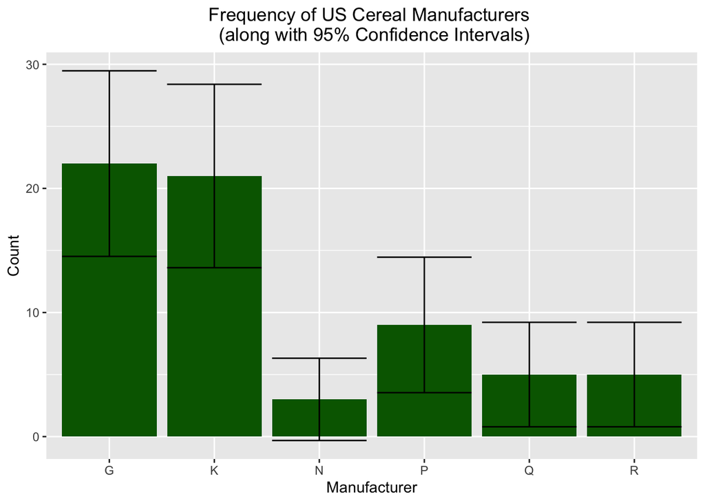

```r
ggplot(data = UScereal.CIs, aes(mfr, counts)) + geom_col(fill = "darkgreen") +
 geom_errorbar(aes(ymin=lower, ymax=upper)) + labs(x = "Manufacturer", y = "Count", title = "Frequency of US Cereal Manufacturers \n (along with 95% Confidence Intervals)") +
theme(plot.title = element_text(hjust = 0.5))
```

So, just uncomment the above code after you’ve defined `UScereal.CIs`. Then, take a moment to add color, appropriate labels, and a title to the plot, as you did in Part B.

6. (6 points) Now we’re going to interpret the confidence intervals you visualized in Part E. Let’s say that [Professor M. Zauner](https://en.wikipedia.org/wiki/Michelle_Zauner) is particularly interested in cereal, and asks the following questions:
- Does it appear that there are any significant differences in counts among manufacturers that *are not* General Mills or Kellogg’s?

*No, it does not appear that there are any significant differences among these manufacturers - the confidence intervals all overlap substantially. That said, we can note that the Nabisco and Post confidence intervals only somewhat overlap, making it (at best) ambiguous whether or not there is a significant difference in frequency between these two manufacturers.*

- For which manufacturers does General Mills appear to have significantly different counts?

*It appears that General Mills has significantly different counts for all manufacturers except Kellogs, because the confidence interval for General Mills does not overlap with any of the other confidence intervals except Kelloggs’. Note that, indeed, the General Mills and Post confidence intervals do not overlap - while it’s hard to tell from the graph alone, we can see this from the confidence intervals we computed in Part D.*

For the above questions, ignore issues of multiple testing; we will address that in the next part. And for each question, explain your reasoning in 1-3 sentences. **Hint**: When answering these questions, it may be helpful to look at the actual confidence intervals you computed in Part D.

7. (8pts) In Part F, Professor Zauner asked you to make several pairwise comparisons between one manufacturer and another. You can find that there are 15 different pairwise comparisons you could make from your bar graph. As a result, if we attempt to make multiple pairwise comparisons from a single graph with 95% confidence intervals, our chance of making a Type 1 error is greater than 5%.

To address this issue, make a bar graph similar to Part E, but with confidence intervals that incorporate the Bonferroni correction for 15 comparisons. (We will discuss the Bonferroni correction in class, but you can also see the hint below if you’re not familiar with this correction.) In other words, your graph here should be exactly the same as the graph in Part E, but with wider confidence intervals that incorporate the Bonferroni correction. Then, outside of your code, discuss (in 1-2 sentences) how you constructed the Bonferroni confidence intervals. After you’ve done that, answer Professor Zauner’s same questions from Part F, but using the graph you’ve made here.

**Hint**: In general, $\alpha$-level confidence intervals are constructed using the Normal quantile $z_{1-\alpha/2}$. When we construct 95% confidence intervals, $\alpha = 0.05$, and thus we use $z_{1 - \alpha/2} = z_{0.975}$ (computed with `qnorm(0.975)`). This is exactly what we did with `propCI()` in Part C, where we set `alpha = 0.05` by default. When we use the Bonferroni correction, $\alpha$ is instead set to $0.05/k$, where $k$ is equal to the number of comparisons. Thus, for this part, all you need to do is appropriately use `propCI()`, which you’ve already written, and then make a new graph.

*First, we will create confidence intervals that incorporate the Bonferroni correction:*

```r
countCIs.bonf = nrow(UScereal)*getPropCI(freqTable, alpha = 0.05/15)

UScereal.CIs.bonf = data.frame(
  mfr = names(table(UScereal$mfr)), #this should be the name of each manufacturer
  counts = as.numeric(table(UScereal$mfr)), #this should be the counts of each manufacturer
  lower = countCIs.bonf[1,], #this should be the lower-bound of the 95% CI
  upper = countCIs.bonf[2,]) #this should be the upper-bound of the 95% CI
```

*Note that our process for creating these confidence intervals is exactly the same as what we did in Part D; the only difference is that we set `alpha = 0.05/15` instead of the default `alpha = 0.05`.*

*Now, here is the desired plot:*

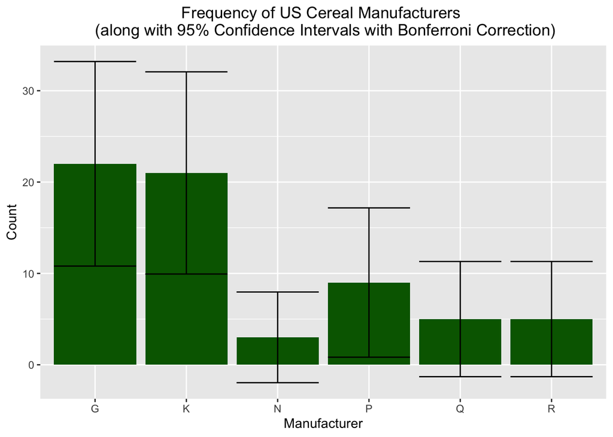

```r
ggplot(data = UScereal.CIs.bonf, aes(mfr, counts)) + geom_col(fill = "darkgreen") +
 geom_errorbar(aes(ymin=lower, ymax=upper)) + labs(x = "Manufacturer", y = "Count", title = "Frequency of US Cereal Manufacturers \n (along with 95% Confidence Intervals with Bonferroni Correction)") +
theme(plot.title = element_text(hjust = 0.5))
```

*Note that all we did was copy-and-paste our code from Part E, but used `UScereal.CIs.bonf` instead of `UScereal.CIs` within `ggplot()`. (We also changed the title slightly.)*

*Now we’ll answer the questions from Part F:*

- Does it appear that there are any significant differences in counts among manufacturers that *are not* General Mills or Kellogg’s?

*No, it does not appear that there are any significant differences among these manufacturers - the confidence intervals all overlap substantially.*

- For which manufacturers does General Mills appear to have significantly different counts?

*It appears that General Mills has significantly different counts from Nabisco - this is actually the only confidence interval that doesn’t overlap with the General Mills confidence interval. Indeed, the Quaker Oats and Ralston Purina confidence intervals do overlap with the General Mills confidence interval:*

```r
UScereal.CIs.bonf
```

```
##   mfr counts      lower     upper
## G   G     22 10.8023598 33.197640
## K   K     21  9.9333308 32.066669
## N   N      3 -1.9652076  7.965208
## P   P      9  0.8267231 17.173277
## Q   Q      5 -1.3058200 11.305820
## R   R      5 -1.3058200 11.305820
```

*However, the confidence intervals overlap so little that General Mills likely has significantly different counts from Quaker Oats and Ralston Purina as well. Notably, it no longer seems to be the case that General Mills has significantly different counts from Post (the confidence intervals now substantially overlap, compared to Part E).*

# Problem 4: Giving a New Order to Categories (15 points)

For this problem, we’ll work with the following dataset, which records all the songs that Professor Branson listened to on Spotify for the past 1.5 years (note that this encompasses only what I listened to during the pandemic, so please don’t judge):

```r
music = read.csv("https://raw.githubusercontent.com/zjbranson/315Fall2021/main/bransonMusic.csv")
```

We will focus on the `day` variable, which records the day of the week a particular song was listened to. Specifically, we will demonstrate how to reorder categories on graphs in `R`. This is particularly useful when visualizing categorical variables, because the plotting order that `R` chooses by default may not be the best choice for your graphs.

1. (3pts): First, make a bar plot of the `day` variable. It’s okay if your plot isn’t properly titled/labeled, but be sure to choose a non-default color. After making your plot, answer the following: What is the default plotting order for categorical (“character” or “factor”) variables in `R`? (You should be able to determine this from glancing at the order of the categories in your graph.)

*Here is a bar plot of the `day` variable:*

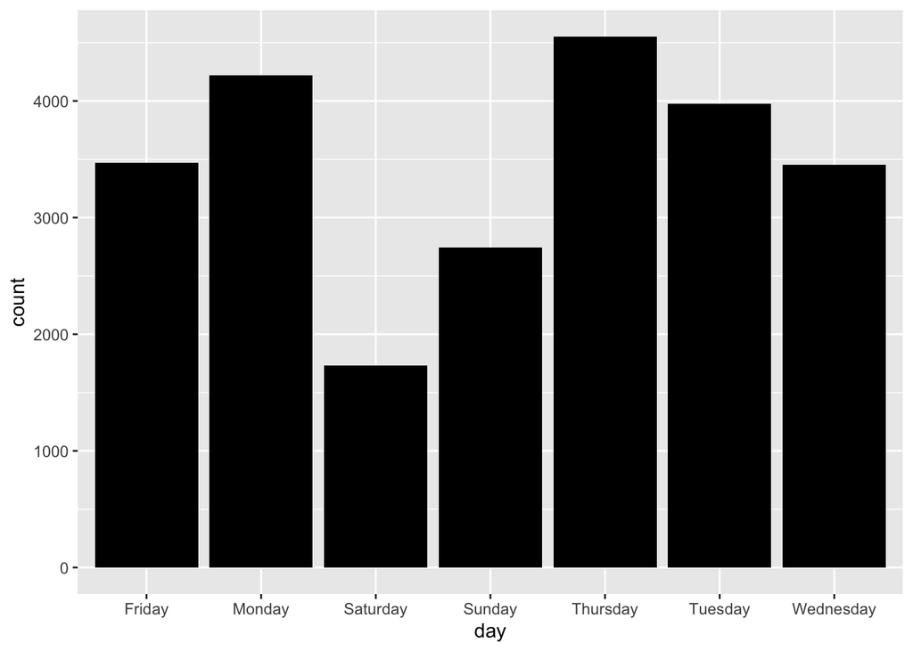

```r
ggplot(music, aes(x = day)) + geom_bar(fill = "black")
```

*We can see that the default for categorical variables in R is to order them alphabetically.*

2. (3pts): Read [this introduction](https://forcats.tidyverse.org/) to the `forcats` package, which was designed to work with categorical data in `R`. The cheatsheet on that page will be particularly useful. Install and load the `forcats` package to your computer. Answer the following:
- What function in the `forcats` package can be used to reorder the levels of a factor in any order you want?

*`fct_relevel` can be used to change the order of a factor by hand.*

- What function in the `forcats` package can be used to reorder the categories from most frequent to least frequent?

*`fct_infreq` can be used to order the factor categories from most frequent to least frequent.*

- What combination of functions in the `forcats` package can be used to reorder the categories from least frequent to most frequent?

*The functions `fct_infreq()` and `fct_rev()` can be used in combination to order the categories from least frequent to most frequent.*

3. (3pts) Recreate the plot in Part A but this time, order the categories from most frequent to least frequent. This time, be sure that your graph is appropriately labeled.

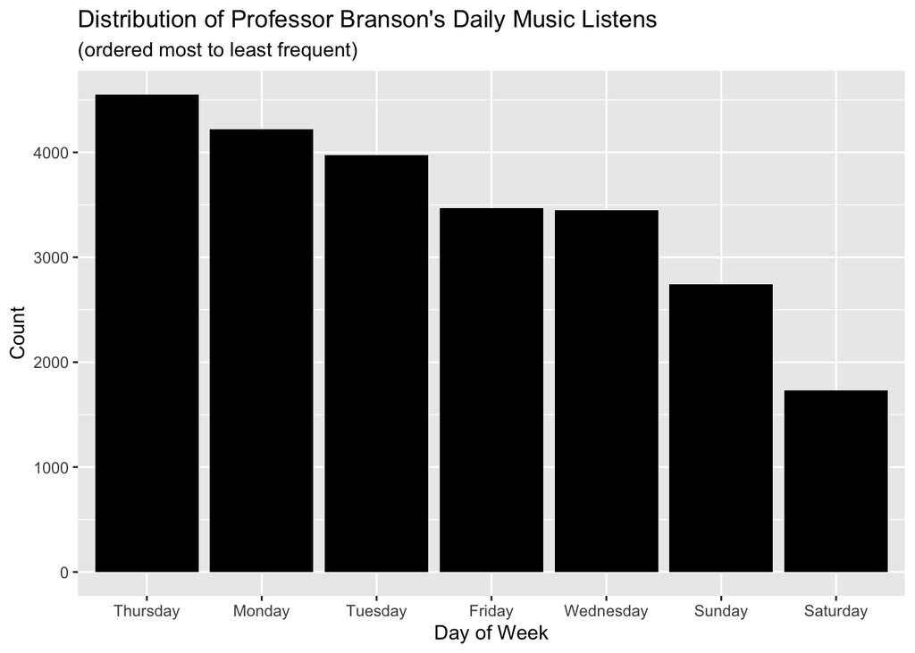

```r
library(forcats)
ggplot(music, aes(x = fct_infreq(day))) + geom_bar(fill = "black") +
  labs(x = "Day of Week", y = "Count",
       title = "Distribution of Professor Branson's Daily Music Listens",
       subtitle = "(ordered most to least frequent)")
```

4. (3pts) Recreate the plot in Part A, but this time, order the categories in a logical order (e.g. Monday, Tuesday, …, Sunday; or Sunday, Monday, …, Saturday). Again, be sure that your graph is appropriately labeled.

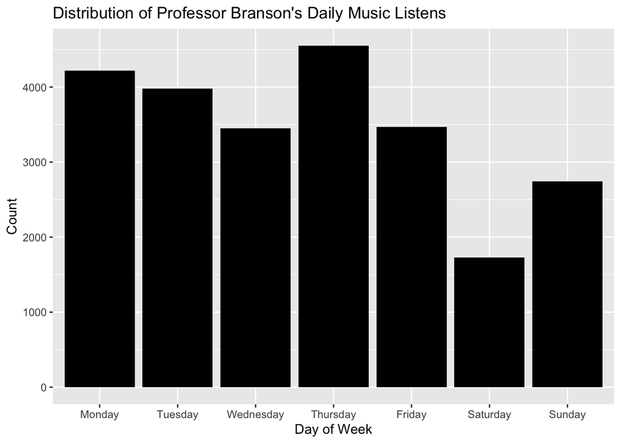

```r
ggplot(music, aes(x = fct_relevel(day,
                                  "Monday",
                                  "Tuesday",
                                  "Wednesday",
                                  "Thursday",
                                  "Friday",
                                  "Saturday",
                                  "Sunday"))) +
  geom_bar(fill = "black") +
  labs(x = "Day of Week", y = "Count",
       title = "Distribution of Professor Branson's Daily Music Listens")
```

5. (3pts) Recreate the plot from the previous part (Part D), but this time, rename the categories so that they use the following day abbreviations: M, Tu, W, Th, F, Sa, Su. **Hint:** Check the help documentation for `fct_recode()`.

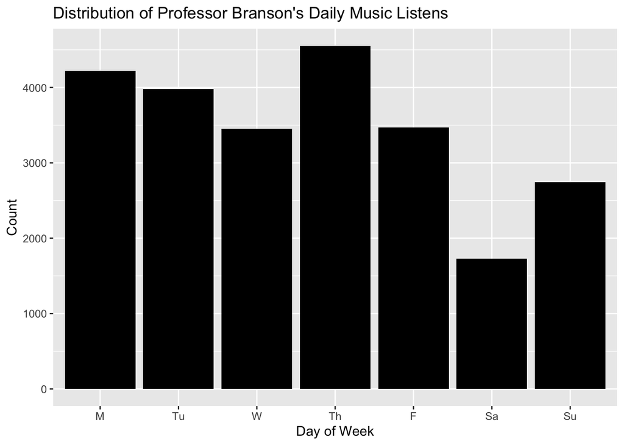

```r
#first, put the days in the right order
music$day = fct_relevel(music$day,
                                  "Monday",
                                  "Tuesday",
                                  "Wednesday",
                                  "Thursday",
                                  "Friday",
                                  "Saturday",
                                  "Sunday")
#now make the plot
ggplot(music, aes(x = fct_recode(day,
                                  "M" = "Monday",
                                  "Tu" = "Tuesday",
                                  "W" = "Wednesday",
                                  "Th" = "Thursday",
                                  "F" = "Friday",
                                  "Sa" = "Saturday",
                                  "Su" = "Sunday"))) +
  geom_bar(fill = "black") +
  labs(x = "Day of Week", y = "Count",
       title = "Distribution of Professor Branson's Daily Music Listens")
```